# Testing Risk Aggregation Function

Andrew Brooks

February 11, 2016

```r
library('rmarkdown')
library('knitr')
library('Rsenal') # devtools::install_github('brooksandrew/Rsenal')
```

## Defining some data to test on

```r
x1 <- abs(rnorm(1000, 3, 1))
x2 <- log(abs(rnorm(1000, 3, 1)))
x3 <- abs(rnorm(1000, 3, 1))^3
x4 <- c(abs(rnorm(995, 3, 1))^3, rnorm(5, 10, .05)^3)
```

## Define aggregation function

```r
normalize <- function(x) (x - min(x, na.rm=T)) / (max(x, na.rm=T)- min(x, na.rm=T))
balscale <- function(x, w_logit=0.85, w_normalized=0.15) plogis(scale(x))*w_logit + normalize(x)*w_normalized
```

`balscale` is the ultimate scaling function used to get all risk indicators from the various models on the same scale ranging from 0 to 100. It is comprised of two parts.

**1) Logistic function of Z-Scores:** Taking Z-scores of each metric would get all indicators on the same scale with similar distributions, (same means quantiles, etc.). However, the scale is centered at 0 (includes negatives) and theoretically unbounded. We desire a bounded scale between 0 and 1. So we pass these Z scores through a logistic function which essentially squashes the data. Rank order is preserved, but the distance between values does change (illustrated in the charts below). Note also that to maintain the same distribution across variables (each variable averages to 0.5) some scaled variables using this method won’t start until a number distinguishably greater than 0, (~0.3 for instance in one of the examples). Likewise, some variables might max out at a number between 0.5 and 1 instead of 1.

**2) Feature Scaling (x - xmin)/(xmax-xmin):** Traditional feature scaling method. Keeps the exact same distribution of raw data, just reassigns scale to be between 0 and 1. This is sensitive to outliers and theoretically could return a value > 1 when scoring new data unless values for the old data are changed.

I experimented with both of these. Curently using a weighted measure which is 85% logistic function of Z scores and 15% feature scaling. The 15% feature scaling allows the data to speak more (preserving more of the original distance between values in the tails) while keeping outliers in check with it’s low weight of 15%.

## Defining function to check the distribution of each

```r
compareFunction <- function(x) {
  xname <- deparse(substitute(x))
  xs <- balscale(x)
  hist(x, main=paste0("raw data: ", xname), breaks=100)
  hist(xs, main=paste0("scaled data: ", xname), breaks=100, xlim=c(0,1))
  #plot(sort(x), main = paste0("raw data sorted: ", xname), xlab="index")
  #plot(sort(xs), main = paste0("scaled data sorted: ", xname), xlab="index")
  plot(x, xs, main= paste0("scaled vs raw data: ", xname), xlab="raw data", ylab="scaled data", cex=0.6)
  kable(do.call(cbind, apply(data.frame(x=x, norm_x=normalize(x), xs=xs), 2, function(x) Rsenal::quantile_df(x, seq(0, 1, .1))))[-c(3,5)])
}
```

## Inspecting scaling function on examples

### Example 1: Normal Distribution

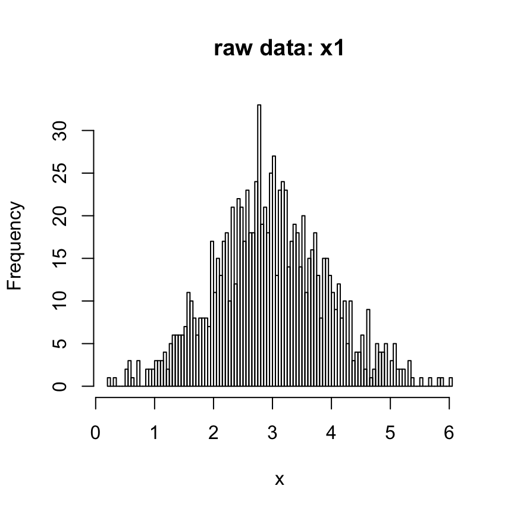

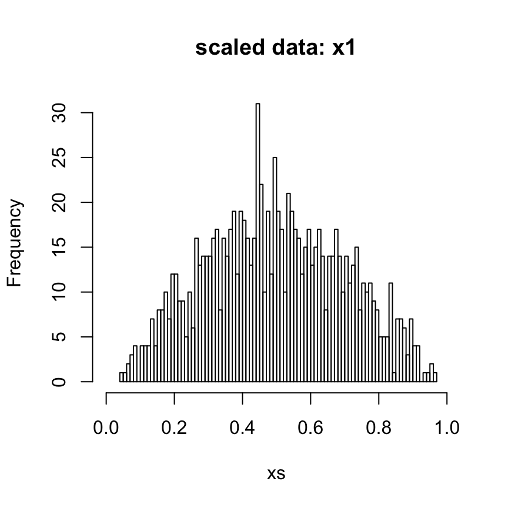

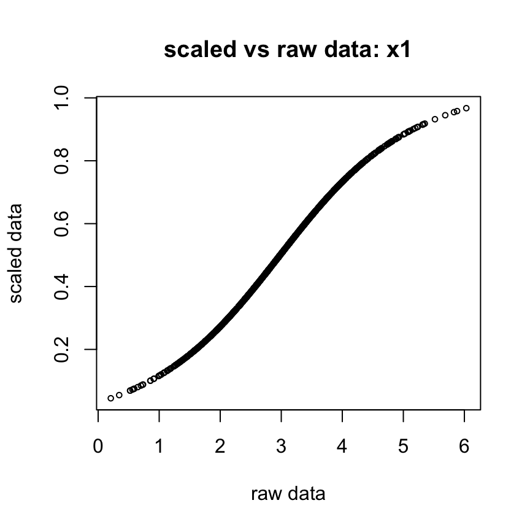

| x.quantile | x.values | norm_x.values | xs.values |
| --- | --- | --- | --- |
| 0% | 0.2073167 | 0.0000000 | 0.0446013 |
| 10% | 1.7296050 | 0.2613705 | 0.2217614 |
| 20% | 2.1755712 | 0.3379410 | 0.3090580 |
| 30% | 2.4691573 | 0.3883485 | 0.3750813 |
| 40% | 2.7358753 | 0.4341428 | 0.4392301 |
| 50% | 2.9466403 | 0.4703303 | 0.4914036 |
| 60% | 3.1603713 | 0.5070270 | 0.5444084 |
| 70% | 3.4379291 | 0.5546825 | 0.6114820 |
| 80% | 3.7539303 | 0.6089386 | 0.6827906 |
| 90% | 4.1894785 | 0.6837204 | 0.7682847 |
| 100% | 6.0315717 | 1.0000000 | 0.9672537 |

```r
compareFunction(x1)
```

### Example 2: Left Skew

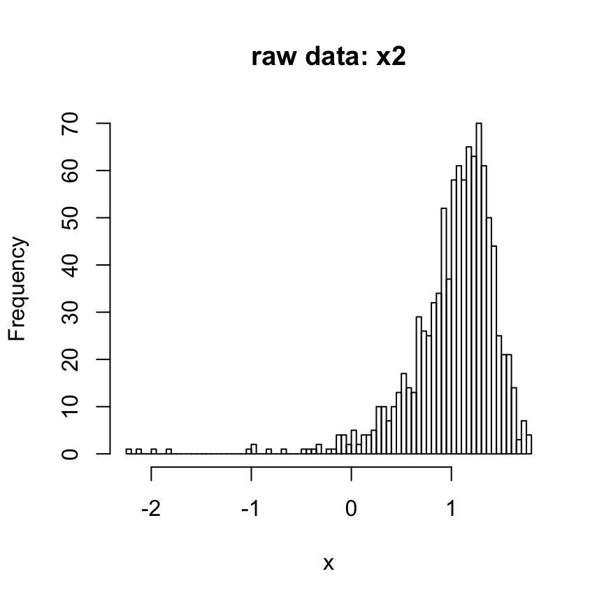

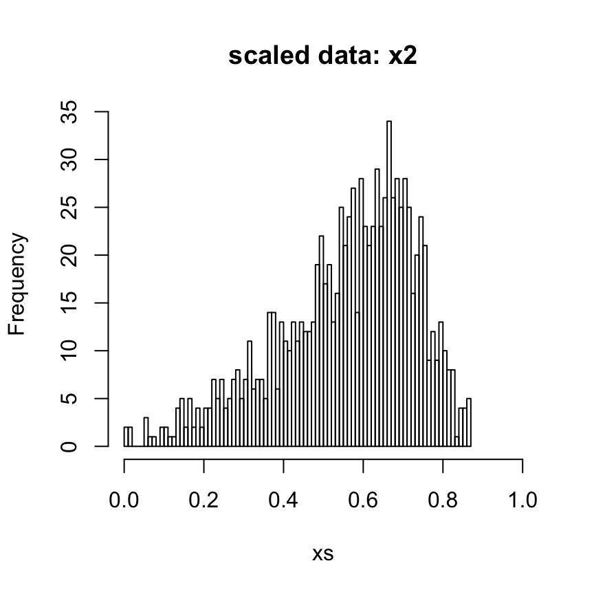

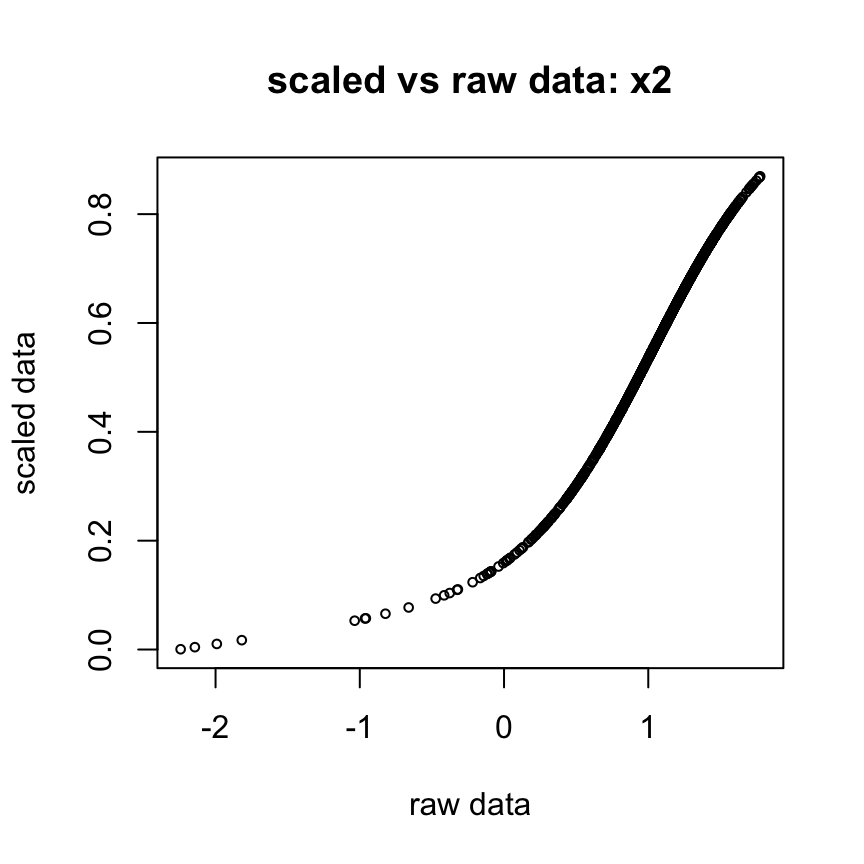

| x.quantile | x.values | norm_x.values | xs.values |
| --- | --- | --- | --- |
| 0% | -2.2421637 | 0.0000000 | 0.0005174 |
| 10% | 0.5185141 | 0.6870815 | 0.3083711 |
| 20% | 0.7583072 | 0.7467616 | 0.4130943 |
| 30% | 0.9142172 | 0.7855647 | 0.4905951 |
| 40% | 1.0211850 | 0.8121870 | 0.5458600 |
| 50% | 1.1070114 | 0.8335476 | 0.5902941 |
| 60% | 1.1920770 | 0.8547189 | 0.6335957 |
| 70% | 1.2627737 | 0.8723140 | 0.6685194 |
| 80% | 1.3420038 | 0.8920329 | 0.7060511 |
| 90% | 1.4429561 | 0.9171580 | 0.7508160 |
| 100% | 1.7758133 | 1.0000000 | 0.8694142 |

```r
compareFunction(x2)
```

### Example 3: Right Skew

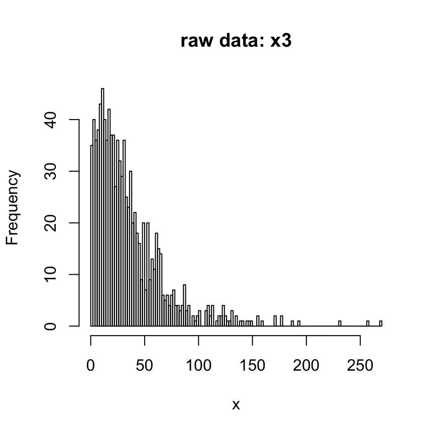

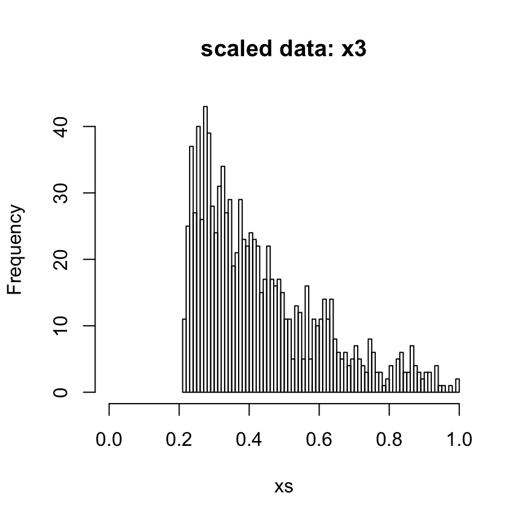

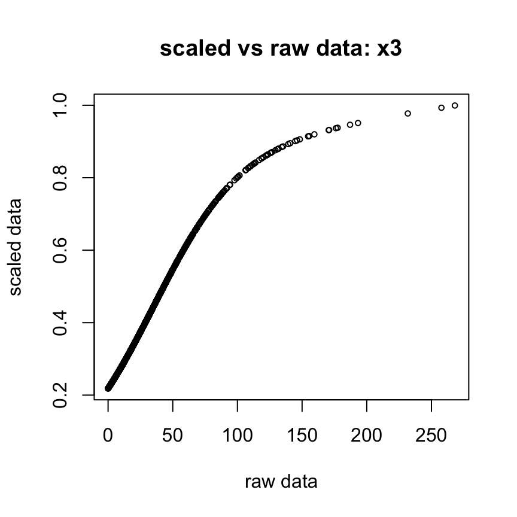

| x.quantile | x.values | norm_x.values | xs.values |
| --- | --- | --- | --- |
| 0% | 0.0000224 | 0.0000000 | 0.2183100 |
| 10% | 5.6547262 | 0.0210894 | 0.2503255 |
| 20% | 10.2831135 | 0.0383511 | 0.2781287 |
| 30% | 15.3390405 | 0.0572073 | 0.3099769 |
| 40% | 20.2164433 | 0.0753977 | 0.3419501 |
| 50% | 26.3590644 | 0.0983068 | 0.3835642 |
| 60% | 32.9023257 | 0.1227101 | 0.4289172 |
| 70% | 40.9440887 | 0.1527021 | 0.4849564 |
| 80% | 54.0430738 | 0.2015552 | 0.5733068 |
| 90% | 73.3654382 | 0.2736185 | 0.6873309 |
| 100% | 268.1303211 | 1.0000000 | 0.9992560 |

```r
compareFunction(x3)
```

### Example 4: Right Skew with Big Outliers

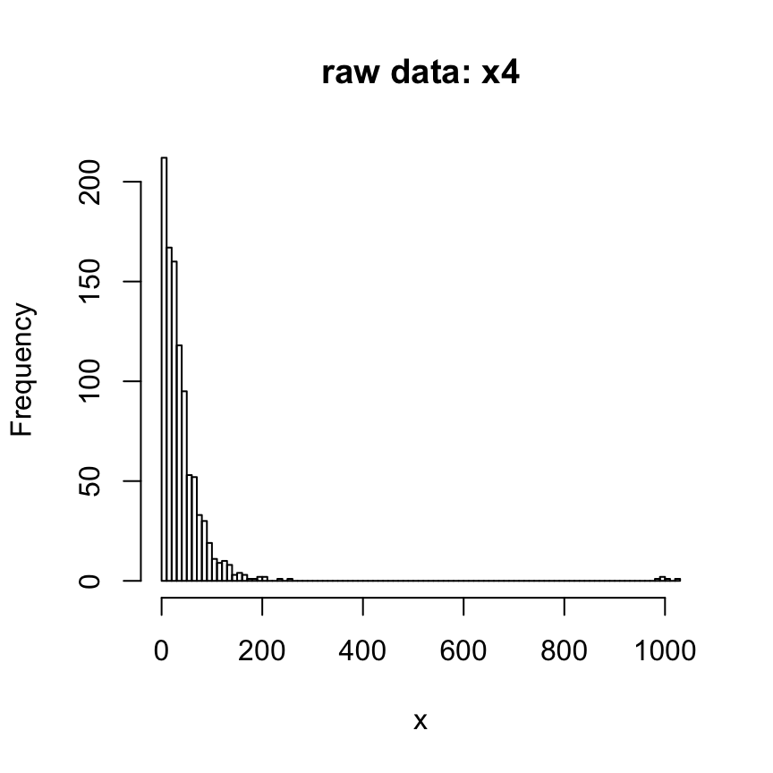

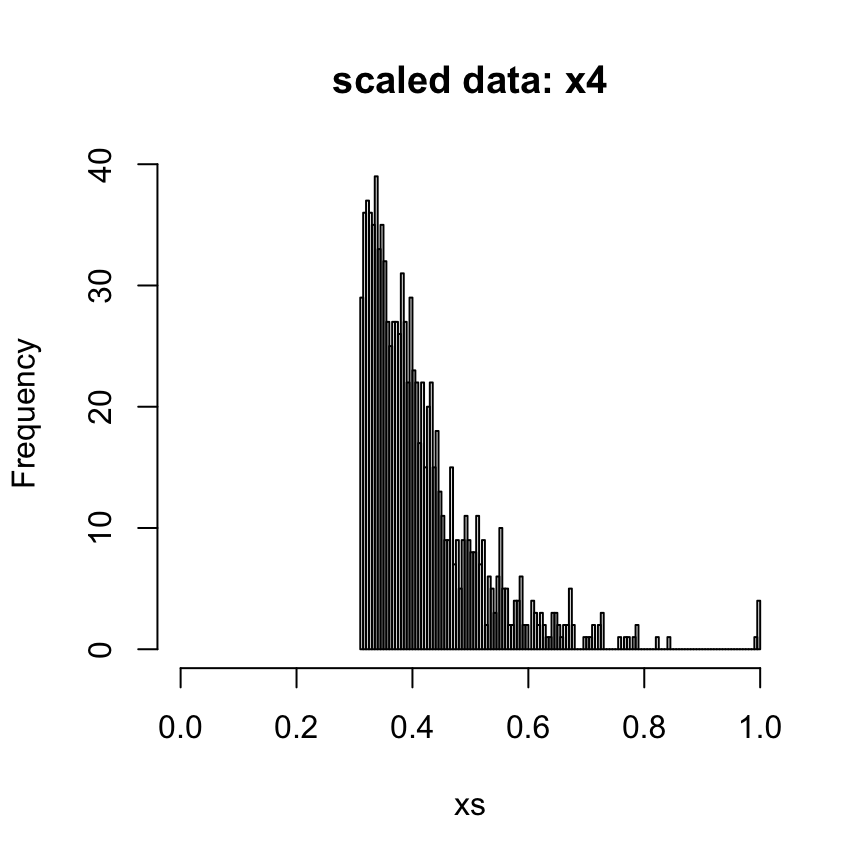

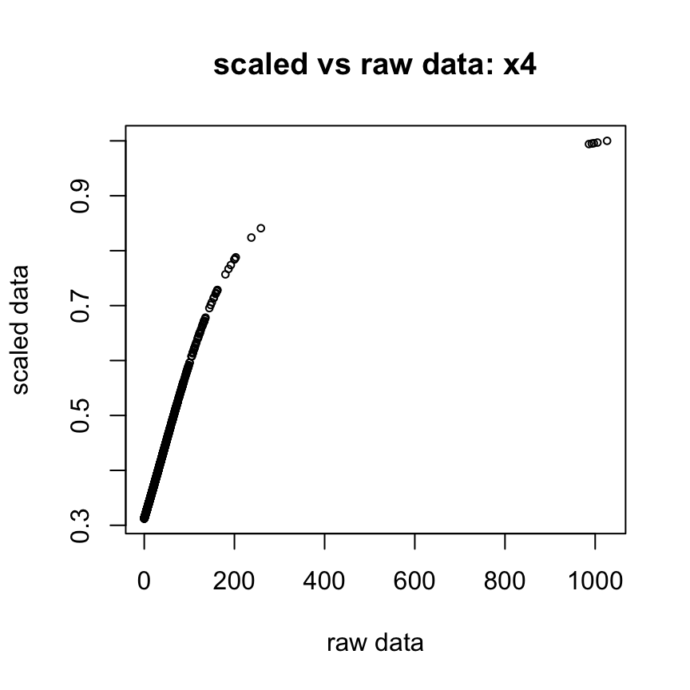

| x.quantile | x.values | norm_x.values | xs.values |
| --- | --- | --- | --- |
| 0% | 0.0003819 | 0.0000000 | 0.3123952 |
| 10% | 4.4737212 | 0.0043583 | 0.3246948 |
| 20% | 9.2560436 | 0.0090175 | 0.3380237 |
| 30% | 14.8106774 | 0.0144293 | 0.3537110 |
| 40% | 21.3209945 | 0.0207721 | 0.3723338 |
| 50% | 27.1935128 | 0.0264935 | 0.3893042 |
| 60% | 34.5355039 | 0.0336466 | 0.4106784 |
| 70% | 43.4920759 | 0.0423728 | 0.4368643 |
| 80% | 57.8081167 | 0.0563205 | 0.4785708 |
| 90% | 83.1578693 | 0.0810181 | 0.5501154 |
| 100% | 1026.4069720 | 1.0000000 | 0.9999978 |

```r
compareFunction(x4)
```

```r
# rmarkdown::render('aggregate_risk/explore_risk_agg_function.R', output_file = 'explore_risk_agg_function.html')
```